# Indel Signature InsDel10

# InsDel10

(corresponds to 83-type signature C_ID10)

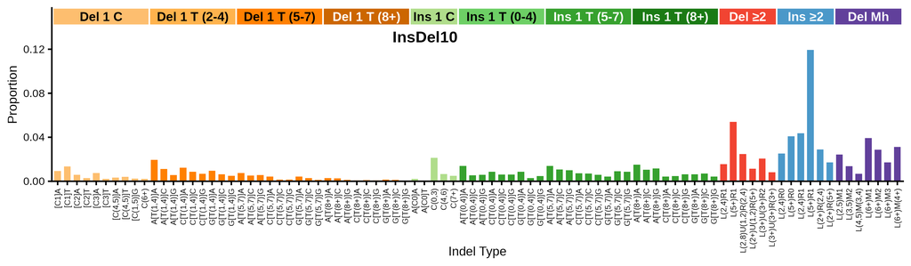

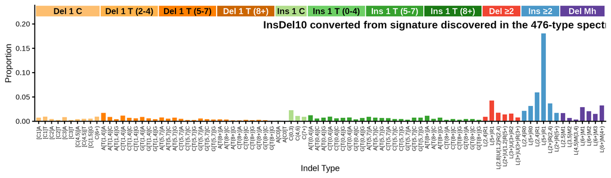

89-type spectrum of the linking tumor SP109957 | cosine similarity to InsDel10: 0.8457

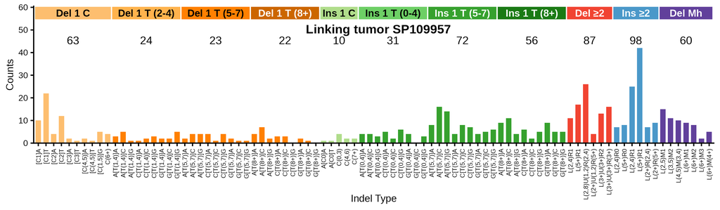

**Click to view decomposition of the linking tumor spectrum**

Partial mutation signature of SP109957 due to InsDel10

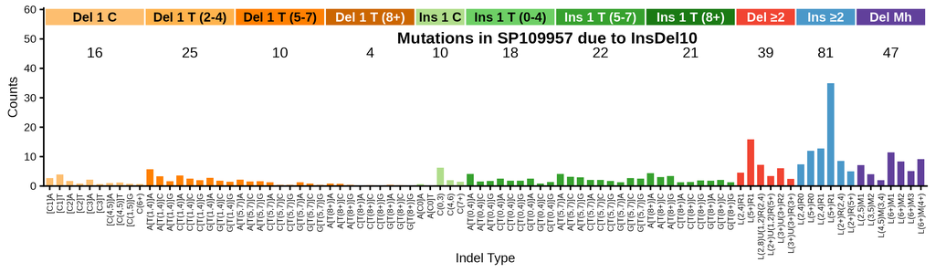

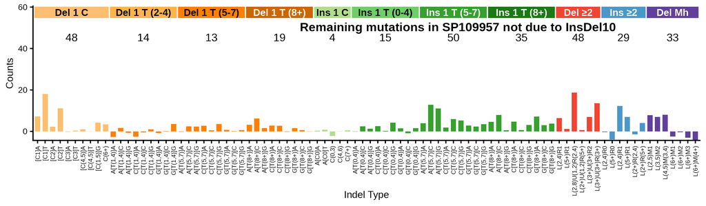

Max neg fraction (maximum allowed negative residual count as fraction of total): 0.05  
N subtract (mutation count assigned to signature): 293.0  
N residual (mutation count in residual “partial spectrum”): 253.0  
Total negative (sum of negative residual mutation counts): 27.3  
N negative channels (number of channels with negative residual): 20  
P(≥ total negative) (Monte Carlo estimated probability that negative-binomial-sampled spectra from the signature contributing N subtract mutations would produce a total negative count >= the observed Total negative; higher number means not surprising): 0.756

**Per-channel residual breakdown**

| Channel | Spectrum | Sig_Count | Residual | Sig_Prop |
| --- | --- | --- | --- | --- |
| [Del(C):R1]A | 10 | 2.7 | 7.3 | 0.00923 |
| [Del(C):R1]T | 22 | 4.0 | 18 | 0.01350 |
| [Del(C):R2]A | 4 | 1.7 | 2.3 | 0.00591 |
| [Del(C):R2]T | 12 | 0.8 | 11.2 | 0.00284 |
| [Del(C):R3]A | 2 | 2.2 | -0.2 | 0.00744 |
| [Del(C):R3]T | 1 | 0.6 | 0.4 | 0.00221 |
| [Del(C):R(4,5)]A | 2 | 1.0 | 1 | 0.00345 |
| [Del(C):R(4,5)]T | 1 | 1.2 | -0.2 | 0.00398 |
| [Del(C):R(1,5)]G | 5 | 0.7 | 4.3 | 0.00248 |
| Del(C):R(6,9) | 4 | 0.6 | 3.4 | 0.00218 |
| A[Del(T):R(1,4)]A | 3 | 5.7 | -2.7 | 0.01937 |
| A[Del(T):R(1,4)]C | 5 | 3.3 | 1.7 | 0.01125 |
| A[Del(T):R(1,4)]G | 1 | 1.7 | -0.7 | 0.00573 |
| C[Del(T):R(1,4)]A | 1 | 3.6 | -2.6 | 0.01230 |
| C[Del(T):R(1,4)]C | 2 | 2.6 | -0.6 | 0.00873 |
| C[Del(T):R(1,4)]G | 3 | 2.0 | 1 | 0.00689 |
| G[Del(T):R(1,4)]A | 2 | 2.8 | -0.8 | 0.00947 |
| G[Del(T):R(1,4)]C | 2 | 1.8 | 0.2 | 0.00628 |
| G[Del(T):R(1,4)]G | 5 | 1.4 | 3.6 | 0.00486 |
| A[Del(T):R(5,7)]A | 2 | 2.2 | -0.2 | 0.00745 |
| A[Del(T):R(5,7)]C | 4 | 1.5 | 2.5 | 0.00529 |
| A[Del(T):R(5,7)]G | 4 | 1.6 | 2.4 | 0.00560 |
| C[Del(T):R(5,7)]A | 4 | 1.3 | 2.7 | 0.00431 |
| C[Del(T):R(5,7)]C | 1 | 0.4 | 0.6 | 0.00145 |
| C[Del(T):R(5,7)]G | 4 | 0.4 | 3.6 | 0.00149 |
| G[Del(T):R(5,7)]A | 2 | 1.2 | 0.8 | 0.00425 |
| G[Del(T):R(5,7)]C | 1 | 0.8 | 0.2 | 0.00281 |
| G[Del(T):R(5,7)]G | 1 | 0.4 | 0.6 | 0.00133 |
| A[Del(T):R(8,)]A | 4 | 0.9 | 3.1 | 0.00292 |
| A[Del(T):R(8,)]C | 7 | 0.7 | 6.3 | 0.00256 |

[output cut: 59 more lines]

## 476-type representations corresponding to InsDel10

Extracted 476-type signature corresponding to InsDel10

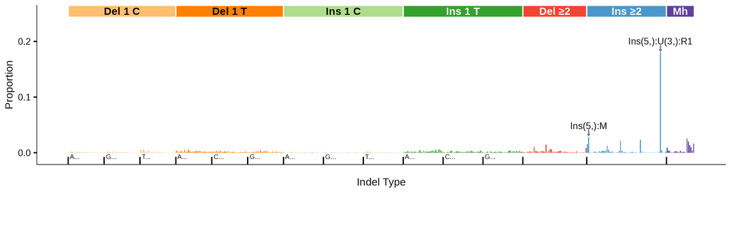

476-type spectrum of the linking tumor SP109957; cosine similarity to the extracted 476-type signature is 0.7964

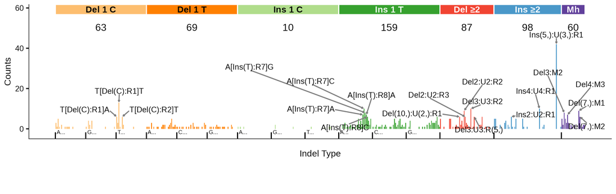

## 83-type signature corresponding to InsDel10 (C_ID10)

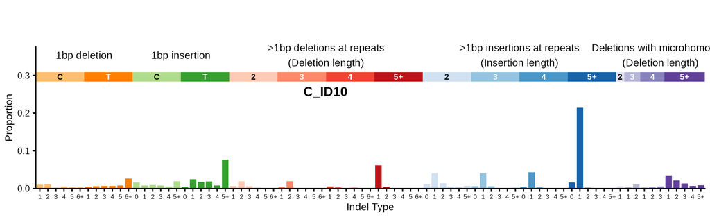

83-type signature converted from signature discovered in the 476-type spectra (using bipartite matching optimization) | cosine similarity to C_ID10: 0.9699

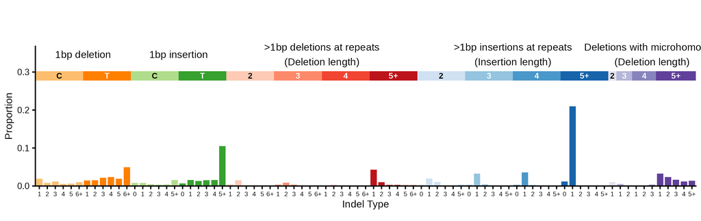

**Click to see flow diagrams: 476-type to 83-type collapse**

These Sankey diagrams show how the 476-type mutation categories are redistributed to 83-type categories using bipartite matching. We only show the diagrams for insertions or deletions of > 1 base because it is for these indels that 476-type categories map to > 1 83-type category.

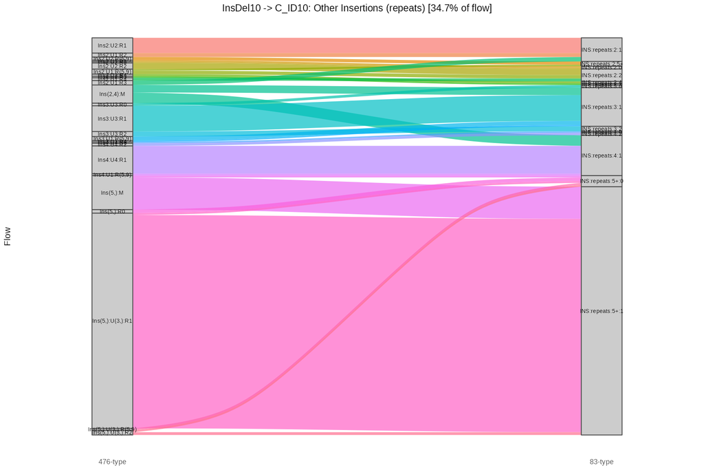

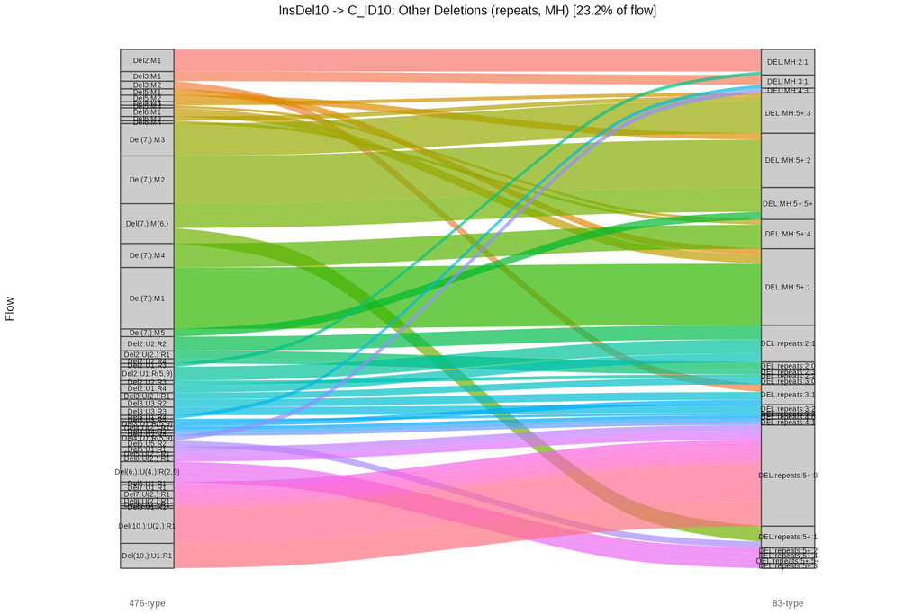

**Caution**

For the linking tumor plot, mutation counts for insertions and deletions of T in long-poly-T contexts were set to 0. They were also set to 0 when calculating cosine similarity with the signature. The signature was not altered when computing the cosine similarity.

83-type spectrum of the linking tumor SP109957 | cosine similarity to C_ID10: 0.7523

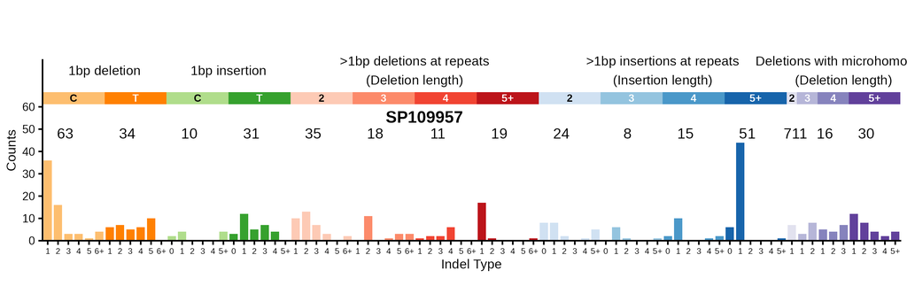

### Similar signatures from Jin et al. 2024

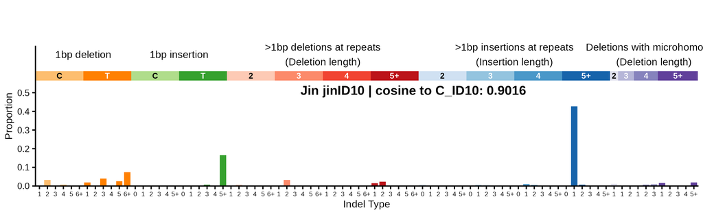

**Click here to see with insertions and deletions of T in long poly-T suppressed**

[figure not shown]